# R Notebook by Morgan Palmer and Surya Poddutoori

```r
library(readxl)
spring_maple_monitoringAug17clean <- read_excel("C:/Users/samee/Google Drive/College/STOR 455/R/Datasets/spring_maple_monitoringAug17clean.xlsx")
```

```r
anovaData = subset(spring_maple_monitoringAug17clean, select=c('Circumference_in', 'Habitat', 'Concrete', 'Latitude', 'Longitude', 'Shading', 'TreeHealth', 'LeavesUnfolded', 'Flowers', 'LeafBuds' ))
anovaData = anovaData[complete.cases(anovaData),]
```

# Section 1: ANOVA Analysis

Use the techniques discussed in class to analyze some aspect of the data using one-way, two-way, and two-way with an interaction ANOVA models. Discuss if the analyzed data meets the conditions for the ANOVA models and analyze the residuals. Also discuss the results of your analysis in the context of the data. Does it make sense to do this analysis given the context?

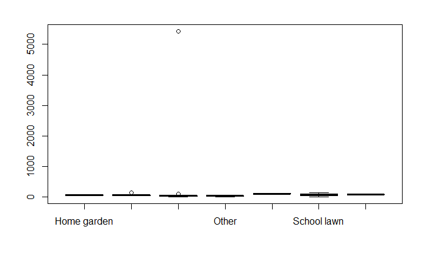

```r
boxplot(Circumference_in~Habitat, data = spring_maple_monitoringAug17clean)
```

# One way Anova

```r
maples = aov(Circumference_in~Habitat, data = anovaData)
summary(maples)
```

```
             Df Sum Sq Mean Sq F value Pr(>F)
Habitat       6 163969   27328   57.07 <2e-16 ***
Residuals   430 205892     479
---
Signif. codes:  0 *** 0.001 ** 0.01 * 0.05 . 0.1   1
```

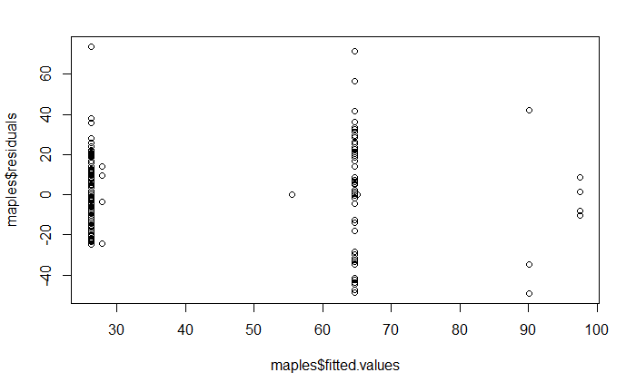

```r
plot(maples$residuals~maples$fitted.values)
```

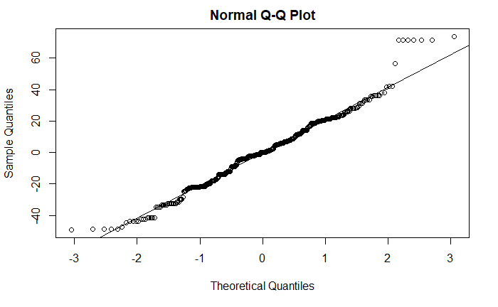

```r
qqnorm(maples$residuals)
qqline(maples$residuals)
```